# Dimensionality reduction techniques

```r
knitr::opts_chunk$set(message = FALSE)
date()
```

```
## [1] "Wed Nov 30 13:00:06 2022"
```

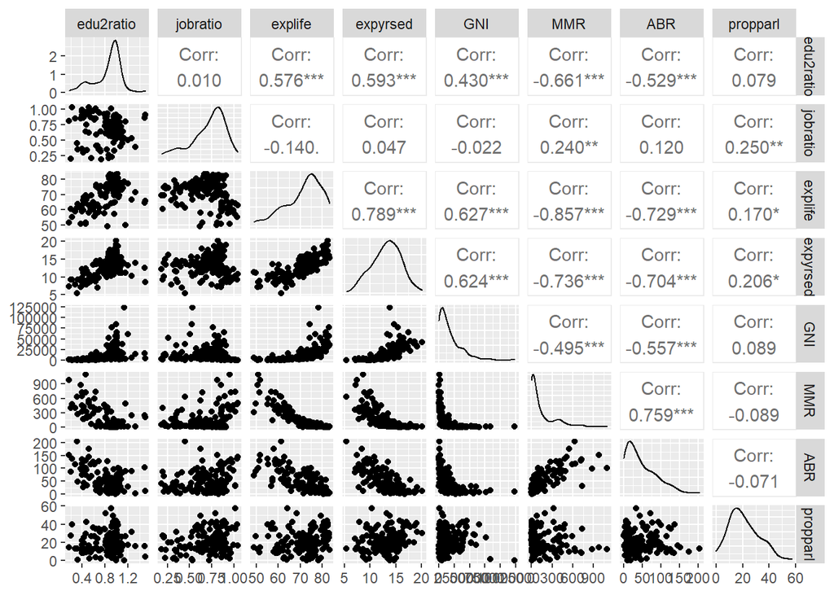

```r
# BRING IN THE DATA

# access packages readr and dplyr
library(readr); library(dplyr)

# Set the working directory
setwd("C:/Users/yona2/Desktop/FT/IODS2022/RStudio/IODS-project/data")

human <- read.csv("human.csv")

# add countries as rownames
rownames(human) <- human$X

# remove the Country variable
human <- select(human, -X)


# EXPLORING THE DATA

# Access GGally and corrplot
library(GGally)
library(corrplot)

# visualize the variables
p <- ggpairs(human, progress = FALSE) # for some reason ggpairs produces error in knitting...
p
```

```r
# compute the correlation matrix and visualize it with corrplot
cor(human) %>% round(digits = 3)
```

```
##           edu2ratio jobratio explife expyrsed    GNI    MMR    ABR propparl
## edu2ratio     1.000    0.010   0.576    0.593  0.430 -0.661 -0.529    0.079
## jobratio      0.010    1.000  -0.140    0.047 -0.022  0.240  0.120    0.250
## explife       0.576   -0.140   1.000    0.789  0.627 -0.857 -0.729    0.170
## expyrsed      0.593    0.047   0.789    1.000  0.624 -0.736 -0.704    0.206
## GNI           0.430   -0.022   0.627    0.624  1.000 -0.495 -0.557    0.089
## MMR          -0.661    0.240  -0.857   -0.736 -0.495  1.000  0.759   -0.089
## ABR          -0.529    0.120  -0.729   -0.704 -0.557  0.759  1.000   -0.071
## propparl      0.079    0.250   0.170    0.206  0.089 -0.089 -0.071    1.000
```

Distributions of the variables are rather skewed and the scales vary much from one variable to another. The variables are reasonably highly correlated with each other, except for labor participation ratio between genders (jobratio) and parliament representation (propparl) which correlated least with the other factors.

```r
# PRINCIPAL COMPONENT ANALYSIS

# perform principal component analysis (with the SVD method)
pca <- prcomp(human)

# summary of pca
summary(pca)
```

```
## Importance of components:
##                              PC1      PC2   PC3   PC4   PC5   PC6    PC7    PC8
## Standard deviation     1.854e+04 185.5219 25.19 11.45 3.766 1.566 0.1912 0.1591
## Proportion of Variance 9.999e-01   0.0001  0.00  0.00 0.000 0.000 0.0000 0.0000
## Cumulative Proportion  9.999e-01   1.0000  1.00  1.00 1.000 1.000 1.0000 1.0000
```

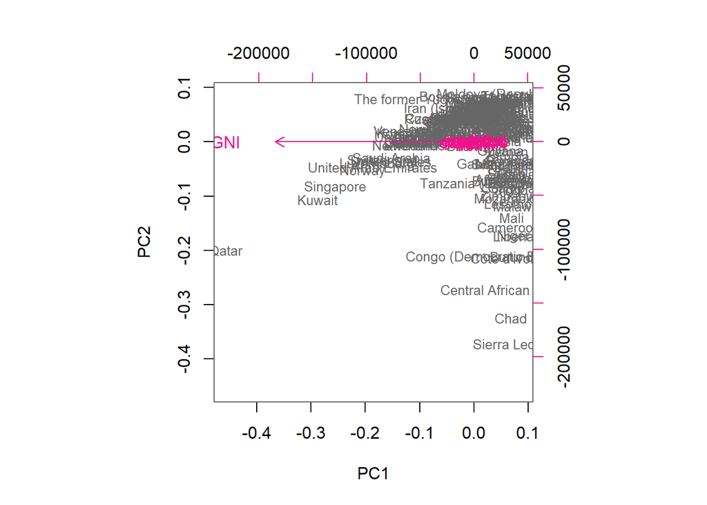

```r
# draw a biplot of the principal component representation and the original variables
biplot(pca, choices = 1:2, col = c("grey40", "deeppink2"), cex = c(0.8, 1))
```

```r
# standardize the variables
human_std <- scale(human)

# print out summaries of the standardized variables
summary(human_std)
```

```
##    edu2ratio          jobratio          explife           expyrsed
##  Min.   :-2.8189   Min.   :-2.6247   Min.   :-2.7188   Min.   :-2.7378
##  1st Qu.:-0.5233   1st Qu.:-0.5484   1st Qu.:-0.6425   1st Qu.:-0.6782
##  Median : 0.3503   Median : 0.2316   Median : 0.3056   Median : 0.1140
##  Mean   : 0.0000   Mean   : 0.0000   Mean   : 0.0000   Mean   : 0.0000
##  3rd Qu.: 0.5958   3rd Qu.: 0.7350   3rd Qu.: 0.6717   3rd Qu.: 0.7126
##  Max.   : 2.6646   Max.   : 1.6632   Max.   : 1.4218   Max.   : 2.4730
##       GNI               MMR               ABR             propparl
##  Min.   :-0.9193   Min.   :-0.6992   Min.   :-1.1325   Min.   :-1.8203
##  1st Qu.:-0.7243   1st Qu.:-0.6496   1st Qu.:-0.8394   1st Qu.:-0.7409
##  Median :-0.3013   Median :-0.4726   Median :-0.3298   Median :-0.1403
##  Mean   : 0.0000   Mean   : 0.0000   Mean   : 0.0000   Mean   : 0.0000
##  3rd Qu.: 0.3712   3rd Qu.: 0.1932   3rd Qu.: 0.6030   3rd Qu.: 0.6127
##  Max.   : 5.6890   Max.   : 4.4899   Max.   : 3.8344   Max.   : 3.1850
```

```r
# compute the correlation matrix and visualize it with corrplot
cor(human_std) %>% round(digits = 3)
```

```
##           edu2ratio jobratio explife expyrsed    GNI    MMR    ABR propparl
## edu2ratio     1.000    0.010   0.576    0.593  0.430 -0.661 -0.529    0.079
## jobratio      0.010    1.000  -0.140    0.047 -0.022  0.240  0.120    0.250
## explife       0.576   -0.140   1.000    0.789  0.627 -0.857 -0.729    0.170
## expyrsed      0.593    0.047   0.789    1.000  0.624 -0.736 -0.704    0.206
## GNI           0.430   -0.022   0.627    0.624  1.000 -0.495 -0.557    0.089
## MMR          -0.661    0.240  -0.857   -0.736 -0.495  1.000  0.759   -0.089
## ABR          -0.529    0.120  -0.729   -0.704 -0.557  0.759  1.000   -0.071
## propparl      0.079    0.250   0.170    0.206  0.089 -0.089 -0.071    1.000
```

```r
# perform principal component analysis (with the SVD method)
pca_std <- prcomp(human_std)

# summary of pca
summary(pca_std)
```

```
## Importance of components:
##                           PC1    PC2     PC3     PC4     PC5     PC6     PC7
## Standard deviation     2.0708 1.1397 0.87505 0.77886 0.66196 0.53631 0.45900
## Proportion of Variance 0.5361 0.1624 0.09571 0.07583 0.05477 0.03595 0.02634
## Cumulative Proportion  0.5361 0.6984 0.79413 0.86996 0.92473 0.96069 0.98702
##                            PC8
## Standard deviation     0.32224
## Proportion of Variance 0.01298
## Cumulative Proportion  1.00000
```

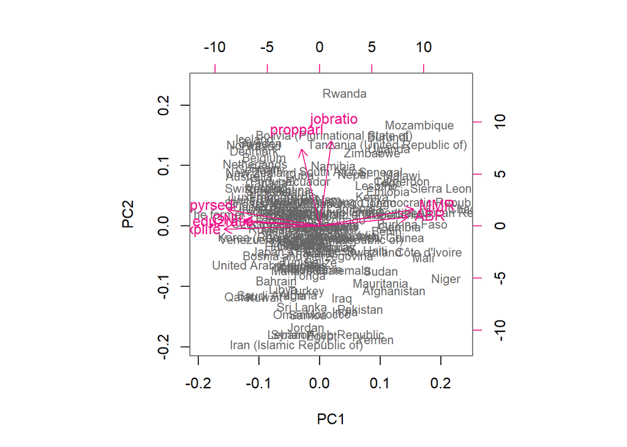

```r
# draw a biplot of the principal component representation and the original variables
biplot(pca_std, choices = 1:2, col = c("grey40", "deeppink2"), cex = c(0.8, 1))
```

As expected, scaling reduces variances. Without scaling, PCA produces components the first of which seems to explain nearly all of the variation in the dataset and is occupied solely with GNI which has the largest variance among the variables. After scaling, PCA produces components the first four of which cumulatively explain 87% of the variation in the data. The arrows present nicely the observed correlations between variables.

```r
# create and print out a summary of pca_std
s <- summary(pca_std)

# rounded percentanges of variance captured by each PC
pca_pr <- round(100*s$importance[2, ], digits = 1)

# print out the percentages of variance
pca_std
```

```
## Standard deviations (1, .., p=8):
## [1] 2.0708380 1.1397204 0.8750485 0.7788630 0.6619563 0.5363061 0.4589994
## [8] 0.3222406
##
## Rotation (n x k) = (8 x 8):
##                   PC1         PC2         PC3         PC4        PC5
## edu2ratio -0.35664370  0.03796058 -0.24223089  0.62678110 -0.5983585
## jobratio   0.05457785  0.72432726 -0.58428770  0.06199424  0.2625067
## explife   -0.44372240 -0.02530473  0.10991305 -0.05834819  0.1628935
## expyrsed  -0.42766720  0.13940571 -0.07340270 -0.07020294  0.1659678
## GNI       -0.35048295  0.05060876 -0.20168779 -0.72727675 -0.4950306
## MMR        0.43697098  0.14508727 -0.12522539 -0.25170614 -0.1800657
## ABR        0.41126010  0.07708468  0.01968243  0.04986763 -0.4672068
## propparl  -0.08438558  0.65136866  0.72506309  0.01396293 -0.1523699
##                   PC6         PC7         PC8
## edu2ratio  0.17713316  0.05773644  0.16459453
## jobratio  -0.03500707 -0.22729927 -0.07304568
## explife   -0.42242796 -0.43406432  0.62737008
## expyrsed  -0.38606919  0.77962966 -0.05415984
## GNI        0.11120305 -0.13711838 -0.16961173
## MMR        0.17370039  0.35380306  0.72193946
## ABR       -0.76056557 -0.06897064 -0.14335186
## propparl   0.13749772  0.00568387 -0.02306476
```

```r
pca_pr
```

```
##  PC1  PC2  PC3  PC4  PC5  PC6  PC7  PC8
## 53.6 16.2  9.6  7.6  5.5  3.6  2.6  1.3
```

```r
# create object pc_lab to be used as axis labels...
paste0(names(pca_pr), " (", pca_pr, "%)")
```

```
## [1] "PC1 (53.6%)" "PC2 (16.2%)" "PC3 (9.6%)"  "PC4 (7.6%)"  "PC5 (5.5%)"
## [6] "PC6 (3.6%)"  "PC7 (2.6%)"  "PC8 (1.3%)"
```